# Solutions

### $\LaTeX$ interpretation

You should quickly realise that $\LaTeX$ is automatically removing the extra white space between words! As such, no matter how many times you consecutively hit the space bar, $\LaTeX$ will interpret it as one space if there are no words in between. This means that you can add extra space between features in your source code without worrying about the effect on the layout of the document you are producing. Of course, you can *force* $\LaTeX$ to put extra white space between your words using commands like `\hspace{2cm}` (forces a fixed gap of 2cm) or using `\ \ \` (each `\` on it's own forces $\LaTeX$ to put an extra space between words) if you want to.

This "removing the excess" also applies to line breaks too. Notice how starting every sentence on a new line in the source code still produces one paragraph in the document:

```
%%pdflatex
When writing a paragraph it can be useful to start each sentence on a new line.
This way, your source code is easier to read.
It also means that if you have any errors in your document, \LaTeX\ will tell you exactly which sentence
is causing the problem. \newline
If you want to force \LaTeX\ to create a new line in the same paragraph,
(you could be writing a poem or sonnet for example),
you can use a double-backslash (\textbackslash\textbackslash), or the \textbackslash newline command.
If you want to start a new paragraph, you can leave a blank line in the source code forcing a newline.
```

[figure not shown]

```
%%pdflatex
I go around in circles, \newline
but always straight ahead. \\
Never complain, \\
wherever I am lead. \\
What am I?
```

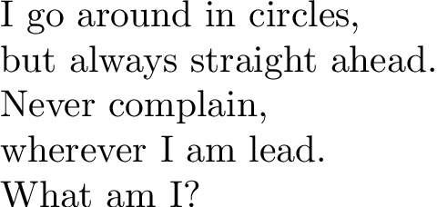

### Your second document

Your $\LaTeX$ source code should look like this:

```
\documentclass{article} %or whatever your favourite document class is, it doesn't matter at this point!

\begin{document}

In March 2006, Congress raised that ceiling an additional \$0.79 trillion to \$8.97 trillion, which is approximately 68 \% of the GDP. As of October 4, 2008, the Emergency Economic Stabilization Act of 2008 raised the current debt ceiling to \$11.3 trillion.

\end{document}
```

```
%%pdflatex
In March 2006, Congress raised that ceiling an additional \$0.79 trillion to \$8.97 trillion,
which is approximately 68 % of the GDP.
As of October 4, 2008, the Emergency Economic Stabilization Act of 2008 raised the current debt
ceiling to \$11.3 trillion.
```

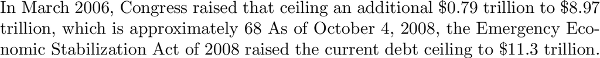